# Domača naloga 5

Linearni modeli

Alen Kahteran

18. 12. 2020

# Avti

Najprej pretvorimo podatke.

```r
Cars93 <- as_tibble(Cars93)
Cars93$Poraba<-235.21/Cars93$MPG.highway  # v l/100 km
Cars93$Masa<-Cars93$Weight*0.45359/100    # v 100 kg
Cars93$Prostornina<-Cars93$EngineSize     # v litrih
Cars93$Moc<-Cars93$Horsepower             # v KM
Cars93$Poreklo<-Cars93$Origin             # Poreeklo
Cars93$Tip<-Cars93$Type                   # Tip

avti <- subset(Cars93, select=c(Poraba, Masa, Prostornina, Moc, Poreklo, Tip))
rownames(avti) <- Cars93$Make

avti$Tip <- relevel(avti$Tip, ref="Van")
```

Za začetek zgradimo osnovni model brez interakcij z vsemi spremenljivkami in si poglejmo diagnostične grafe ostankov, da vidimo če imamo kakšno težavo.

```r
mod_0 <- lm(Poraba~Masa + Prostornina + Moc + Poreklo + Tip, data=avti)
```

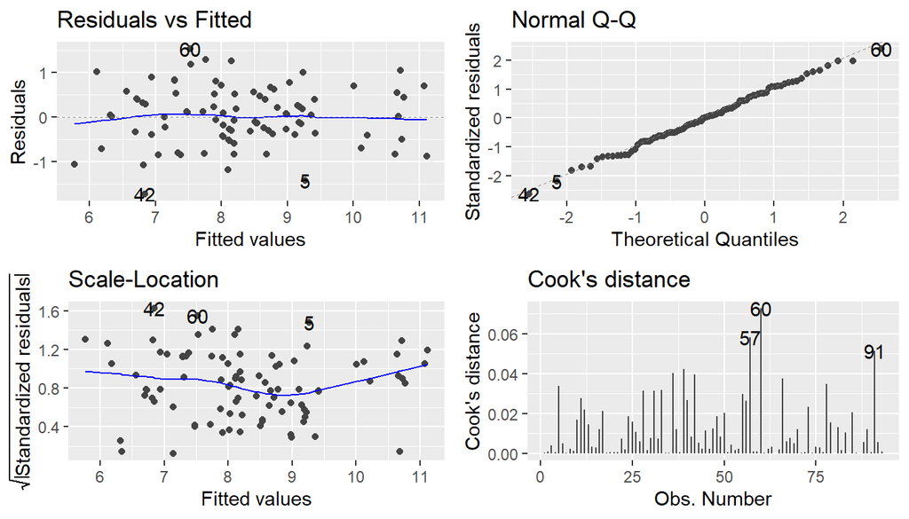

Vidimo da z ostanki ni težav, zato izračunajmo $VIF$ da vidimo če mogoče obstaja kolinearnost med spremenljivkami.

```r
vif(mod_0)
```

```
##                  GVIF Df GVIF^(1/(2*Df))
## Masa        12.248412  1        3.499773
## Prostornina  6.230114  1        2.496020
## Moc          3.904329  1        1.975938
## Poreklo      1.455586  1        1.206477
## Tip          9.750209  5        1.255745
```

Videti je, da spremenljivka `Masa` izstopa, in je zato smiselno ponoviti postopek, le da tokrat brez spremenljivke `Masa`.

```r
mod_1 <- lm(Poraba~Prostornina + Moc + Poreklo + Tip, data=avti)
```

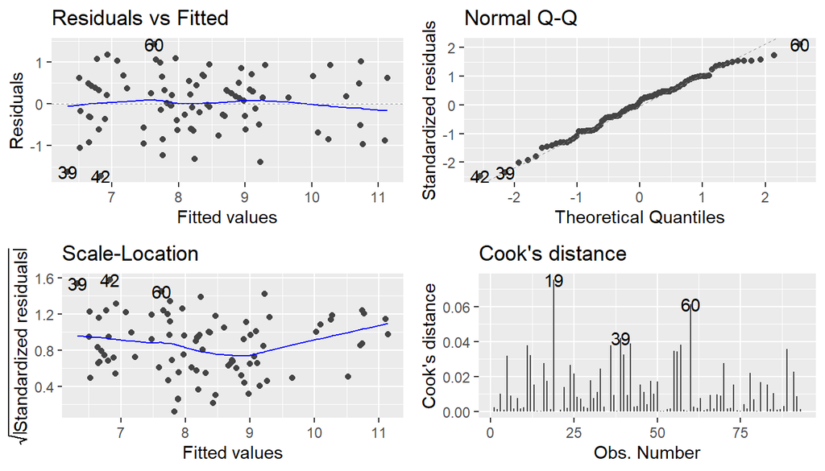

Zopet vidimo da večjih težav ni, predpostavke bi rekel da so izpolnjene. Poglejmo si zato zopet $VIF$.

```r
vif(mod_1)
```

```
##                 GVIF Df GVIF^(1/(2*Df))
## Prostornina 4.783101  1        2.187030
## Moc         3.057284  1        1.748509
## Poreklo     1.433809  1        1.197418
## Tip         3.197163  5        1.123250
```

Tokrat vidimo, da težav nimamo.

Da preverimo morebitno korelacijo med napovednimi spremenljivkami, je potrebno vedeti kakšna je približna odvisnost, zato da vemo katero metodo izračuna korelacije bomo uporabili.

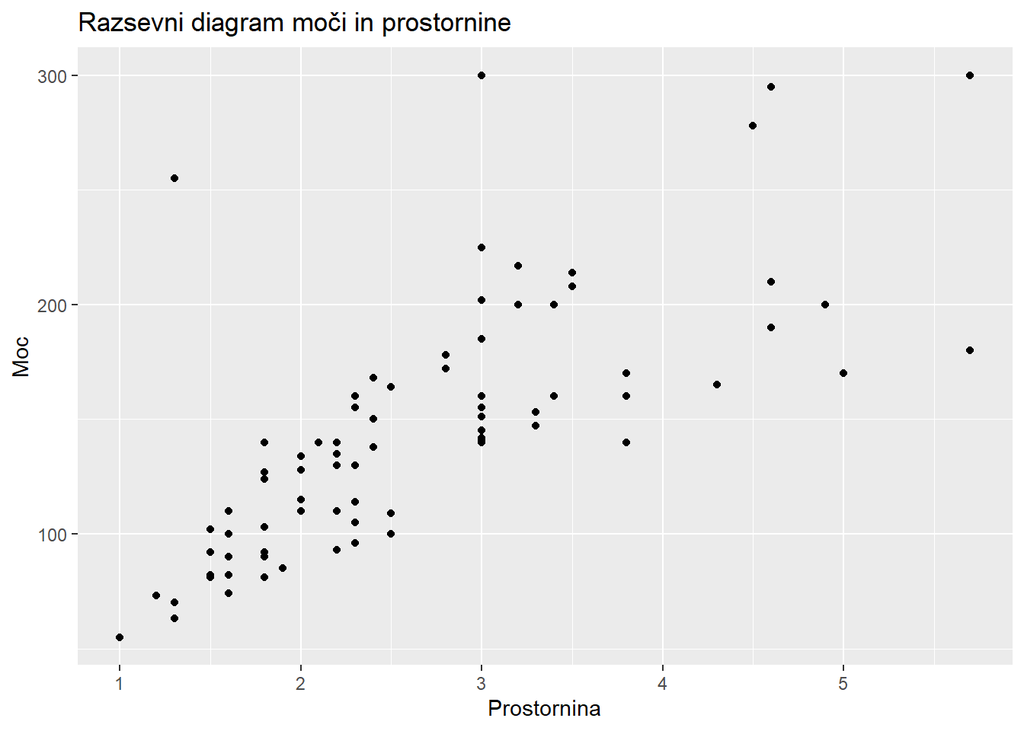

Vidimo da obstaja linearna povezanost, zato lahko uporabimo Pearsonov koeficient korelacije.

```r
cor(avti %>% select(Prostornina, Moc), method="pearson")
```

```
##             Prostornina       Moc
## Prostornina   1.0000000 0.7321197
## Moc           0.7321197 1.0000000
```

Torej vidimo da imamo še vedno težavo s kolinearnostjo. Da bomo prepričani v to, preverimo še napovedne grafe.

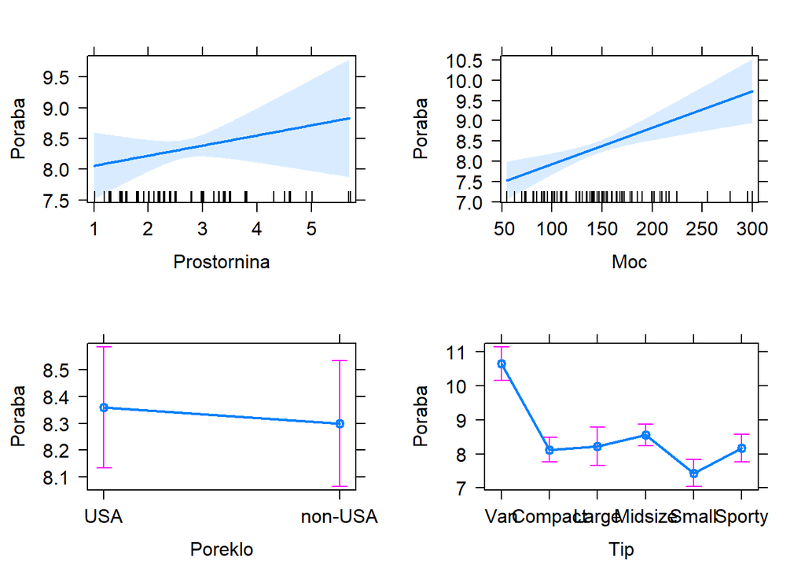

Vidimo da `Prostornina` predstavlja večjo težavo (intervali zaupanja). Poglejmo kako izgleda model še brez spremenljivke `Prostornina`.

```r
mod_2 <- lm(Poraba~Moc + Poreklo + Tip, data=avti)
```

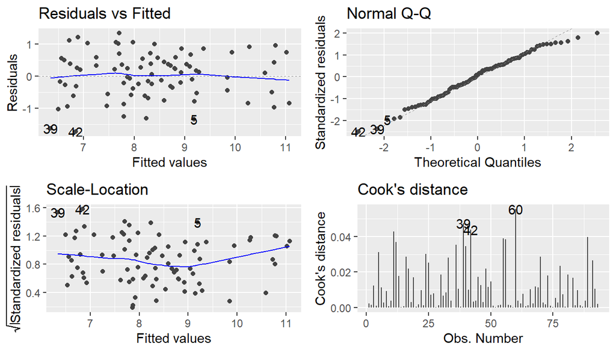

```r
vif(mod_2)
```

```
##             GVIF Df GVIF^(1/(2*Df))
## Moc     1.658608  1        1.287869
## Poreklo 1.195126  1        1.093218
## Tip     1.944036  5        1.068736
```

Vidimo da so predpostavke o modelu izpolnjene. Na nobenem izmed diagnostičnih grafov ne vidimo težav. $VIF$ vrednosti so tudi vredu. Korelacije nima več smisla računati saj imamo le še eno številsko napovedno spremenljivko. Sedaj si poglejmo izračunane koeficiente za naš model. Naredili smo model več regresijskih premic (Vse možne kombinacije `Tip` in `Poreklo` za napovedno spremenljivko `Moc`).

```r
res <- glht(mod_2)

summary(res)
```

```
##
##   Simultaneous Tests for General Linear Hypotheses
##
## Fit: lm(formula = Poraba ~ Moc + Poreklo + Tip, data = avti)
##
## Linear Hypotheses:
##                      Estimate Std. Error t value Pr(>|t|)
## (Intercept) == 0     9.245962   0.363112  25.463   <1e-04 ***
## Moc == 0             0.010727   0.001829   5.863   <1e-04 ***
## Poreklonon-USA == 0 -0.136987   0.161874  -0.846    0.934
## TipCompact == 0     -2.631609   0.300107  -8.769   <1e-04 ***
## TipLarge == 0       -2.352328   0.334662  -7.029   <1e-04 ***
## TipMidsize == 0     -2.152812   0.285831  -7.532   <1e-04 ***
## TipSmall == 0       -3.359292   0.307353 -10.930   <1e-04 ***
## TipSporty == 0      -2.615542   0.305542  -8.560   <1e-04 ***
## ---
## Signif. codes:  0 '***' 0.001 '**' 0.01 '*' 0.05 '.' 0.1 ' ' 1
## (Adjusted p values reported -- single-step method)
```

```r
summary(mod_2)$r.squared
```

```
## [1] 0.7565338
```

```r
confint(res)
```

```
##
##   Simultaneous Confidence Intervals
##
## Fit: lm(formula = Poraba ~ Moc + Poreklo + Tip, data = avti)
##
## Quantile = 2.7071
## 95% family-wise confidence level
##
##
## Linear Hypotheses:
##                     Estimate  lwr       upr
## (Intercept) == 0     9.245962  8.262984 10.228940
## Moc == 0             0.010727  0.005774  0.015679
## Poreklonon-USA == 0 -0.136987 -0.575196  0.301222
## TipCompact == 0     -2.631609 -3.444026 -1.819192
## TipLarge == 0       -2.352328 -3.258291 -1.446366
## TipMidsize == 0     -2.152812 -2.926582 -1.379041
## TipSmall == 0       -3.359292 -4.191325 -2.527260
## TipSporty == 0      -2.615542 -3.442673 -1.788411
```

Vidimo, da so vse vrednosti statistično značilne z izjemo spremenljivke `Poreklo`. Torej ne moremo trditi da sta začetni vrednosti za `Poreklo` različni. V ostalih primerih, lahko trdimo da obstajajo razlike. Poglejmo si to še na naslednji sliki

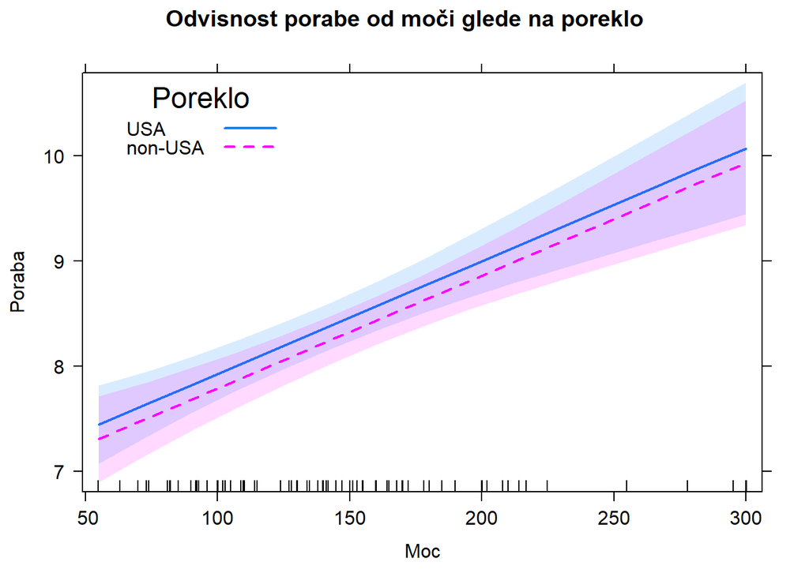

Vidimo da sta obe regresijski črti vsebovani v intervalu zaupanja druge. To je lep grafičen prikaz statistične neznačilnosti spremenljivke `Poreklo`.

Če interpretiramo rezultate v sklopu začetnih vprašanj, izgleda tako:

1. Poraba goriva je odvisna tehničnih karakteristik avta. Videli smo da je večina informacij o spremenljivki `Masa` najverjetneje vsebovana v ostalih spremenljivkah saj je imela zelo visoko vrednost $VIF$ (Sumim da je večina informacije v spremenljivki `Tip`). Poleg tega pa smo videli da sta `Prostornina` in `Moč` zelo linearno povezana. Ker obe spremenljivki govorita o enaki informaciji, smo posledično odstranili spremenljivko `Prostornina` iz modela. Zato je naša najbolj informativna spremenljivka o porabi ravno `Moč`.
2. Poraba goriva je tudi odvisna od tipa avtomobila. Statistično značilno ima vsak tip avtomobila drugačno začetno vrednost.
3. Ne moremo trditi da ima spremenljivka `Poreklo` vpliv na porabo pri avtomobilih.

# Telesna masa in višina žensk

Najprej si poglejmo razsevni diagram teh podatkov.

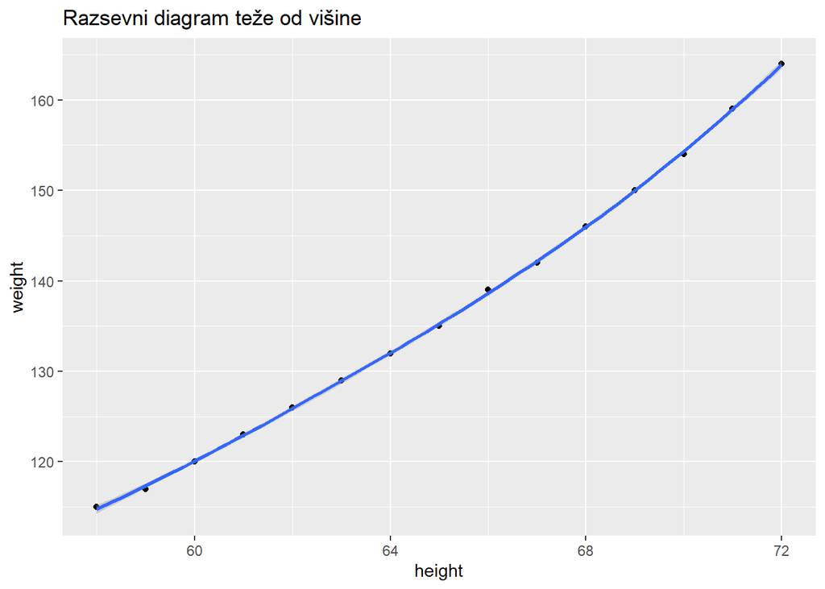

Vidimo manjšo uklonjenost našega gladilnika. Poglejmo si diagnostične grafe linearnega modela spremenljivke `weight` v odvisnosti od spremenljivke `height`.

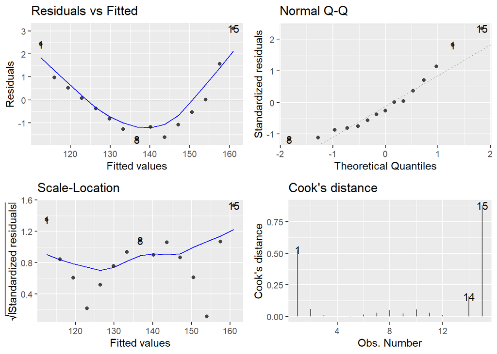

```r
mod_0 <- lm(weight~height, data=women)
autoplot(mod_0, which=1:4)
```

Zelo hitro vidimo da imamo veliko težavo z nelinearnostjo. Poskusimo najprej rešiti model s kvadratnim polinomom.

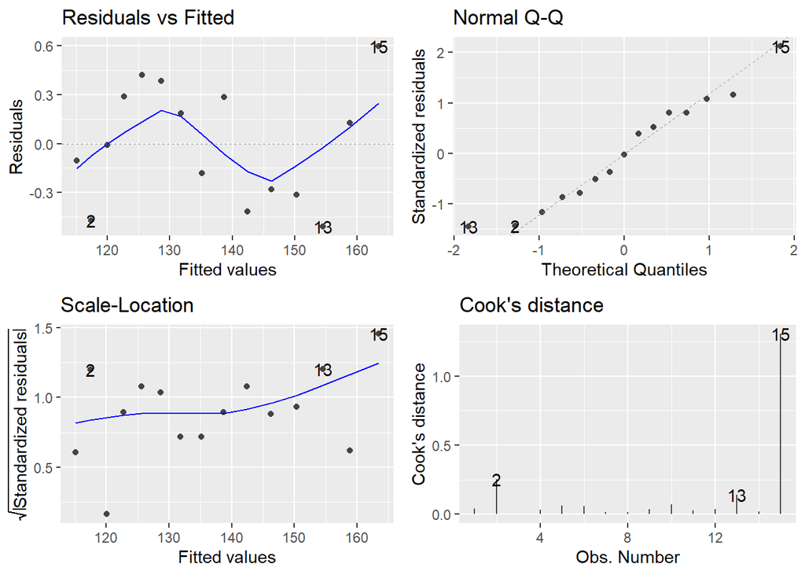

```r
mod_1 <- lm(weight~poly(height, degree=2, raw=TRUE), data=women)

autoplot(mod_1, which=1:4)
```

Vidimo da imamo še vedno težave z nelinearnostjo. Najprej z $ANOVA$ preverimo, če sta modela ekvivalentna.

```r
anova(mod_0, mod_1)
```

```
## Analysis of Variance Table
##
## Model 1: weight ~ height
## Model 2: weight ~ poly(height, degree = 2, raw = TRUE)
##   Res.Df     RSS Df Sum of Sq      F    Pr(>F)
## 1     13 30.2333
## 2     12  1.7701  1    28.463 192.96 9.322e-09 ***
## ---
## Signif. codes:  0 '***' 0.001 '**' 0.01 '*' 0.05 '.' 0.1 ' ' 1
```

Ker modela nista ekvivalentna, lahko dodamo še eno stopnjo več. Poskusimo torej še s polinomom tretje stopnje.

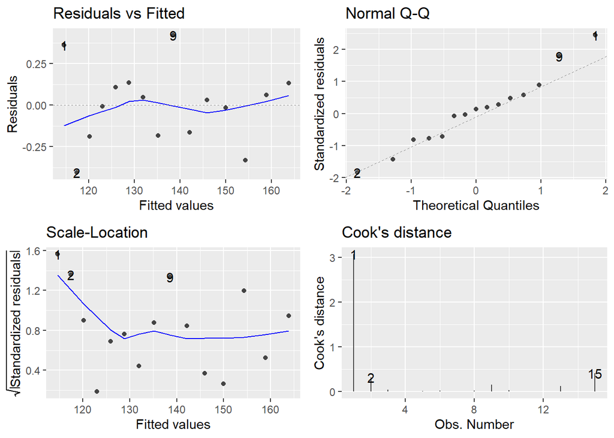

```r
mod_2 <- lm(weight~poly(height, degree=3, raw=TRUE), data=women)

autoplot(mod_2, which=1:4)
```

```r
anova(mod_1, mod_2)
```

```
## Analysis of Variance Table
##
## Model 1: weight ~ poly(height, degree = 2, raw = TRUE)
## Model 2: weight ~ poly(height, degree = 3, raw = TRUE)
##   Res.Df     RSS Df Sum of Sq      F   Pr(>F)
## 1     12 1.77007
## 2     11 0.73415  1    1.0359 15.522 0.002313 **
## ---
## Signif. codes:  0 '***' 0.001 '**' 0.01 '*' 0.05 '.' 0.1 ' ' 1
```

Še vedno imamo manjše težave z nelinearnostjo. Ne vidim veliko smisla v večanju stopnje polinoma, saj imamo le 15 zapisov. Kmalu bomo začeli modelirati že varianco. Poskusimo še z logaritemsko transformacijo odzivne spremenljivke, mogoče se bo stanje izboljšalo.

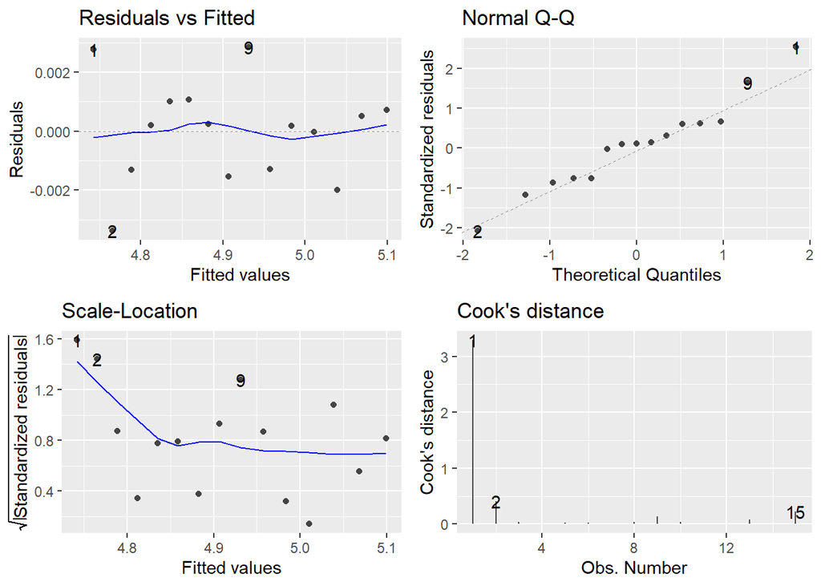

```r
mod_2.1 <- lm(log(weight)~poly(height, degree=3, raw=TRUE), data=women)

autoplot(mod_2.1, which=1:4)
```

Precej smo izboljšali linearnost, ostanki so dokaj normalno porazdeljeni, vidimo pa da varianca zagotovo ni konstantna. To lahko pripišemo prvi točki (mogoče tudi drugi), za katero tudi vidimo da je zelo vplivna. Točk ne bi odstranjevali saj imamo le 15 zapisov. Če zanemarimo prvi dve točki, bi lahko rekli da je varianca konstantna.

Z zlepki najverjetneje ne bi rešili teh težav saj imamo le 15 zapisov.

Poglejmo si izračunane koeficiente

```
##
## Call:
## lm(formula = log(weight) ~ poly(height, degree = 3, raw = TRUE),
##     data = women)
##
## Residuals:
##       Min        1Q    Median        3Q       Max
## -0.003386 -0.001298  0.000198  0.000871  0.002853
##
## Coefficients:
##                                         Estimate Std. Error t value Pr(>|t|)
## (Intercept)                           -1.007e+00  2.175e+00  -0.463   0.6524
## poly(height, degree = 3, raw = TRUE)1  2.423e-01  1.008e-01   2.403   0.0350 *
## poly(height, degree = 3, raw = TRUE)2 -3.633e-03  1.554e-03  -2.337   0.0393 *
## poly(height, degree = 3, raw = TRUE)3  2.008e-05  7.969e-06   2.520   0.0285 *
## ---
## Signif. codes:  0 '***' 0.001 '**' 0.01 '*' 0.05 '.' 0.1 ' ' 1
##
## Residual standard error: 0.001907 on 11 degrees of freedom
## Multiple R-squared:  0.9998, Adjusted R-squared:  0.9997
## F-statistic: 1.631e+04 on 3 and 11 DF,  p-value: < 2.2e-16
```

Vidimo da so naši koeficienti statistično značilni.

```
## [1] 0.9997752
```

Z našim modelom lahko razložimo $99.98\%$ variance.

Z našim modelom opišemo logaritem teže žensk iz Združenih Držav Amerike starih od 30-39 s polinomom tretje stopnje. Oblika je sledeča

Poglejmo si še graf naše napovedi.

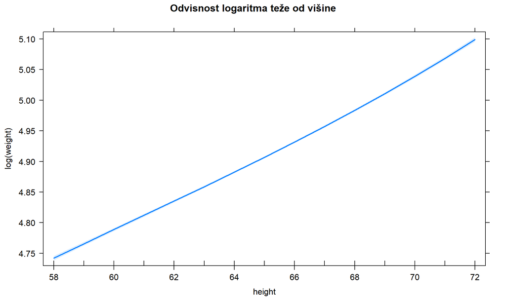